# Lab Exercises 1 Solutions

### (e)

Discuss the (non)informativeness of a flat prior for $\alpha$ and $\beta$. Hint: also consider the case of a single predictor variable that, like the response variable, is 0/1.

Given the logit metric of the response variable it is not clear whether flat priors are so noninformative here. In the extreme case of the 0/1 predictor variable we have, in effect a two-proportion comparison. A flat prior in the logit metric framework would seem to correspond to the Haldane prior in the regular proportion metric quite informative for extreme data. Also see an editorial by Gelman (from BDA) & Jakulin (2007, Statistica Sinica) at http://www.stat.columbia.edu/~gelman/research/published/radical.pdf

### (f)

Find an estimate and 95% interval for the LD50 (the dosage where 50% of the animals die, i.e. p = 0.5).

LD50 = dosage required for p = 0.5. But we know that

$$p = 0.5 = \frac{exp(\alpha + \beta x)}{1 + exp(\alpha + \beta x)} \implies log\left(\frac{p}{1-p}\right) = 0 = \alpha + \beta x \implies x = -\frac{\alpha}{\beta}$$

The LD50 point is the negative ratio of the parameters. We can generate a sample of this using our MC sample of $\alpha$ and $\beta$ above:

```r
ld50 <- -a1/b1
mean(ld50)
```

```
## [1] -0.1058608
```

```r
quantile(ld50,c(0.025,0.975))
```

```
##       2.5%      97.5%
## -0.2708635  0.1093212
```

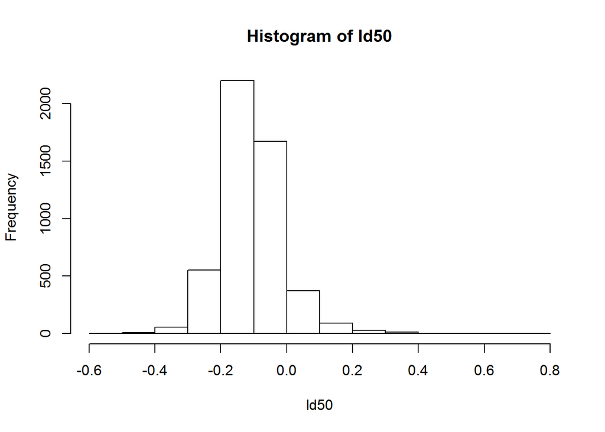

```r
hist(ld50)
```

### (g)

What is the conclusion of this experiment?

The drug has a significantly positive effect on probability of death in these animals (since $\beta > 0$). In fact $Pr( \beta > 0\mid y) = length(b1[b1>0])/5000 = 1 > 4999/5000 = 0.9998$.